# Customer Segmentation using Clustering

This mini-project is based on [this blog post](http://blog.yhat.com/posts/customer-segmentation-using-python.html) by yhat. Please feel free to refer to the post for additional information, and solutions.

```python
%matplotlib inline
import matplotlib.pyplot as plt
import seaborn as sns
import pandas as pd
import numpy as np
import sklearn


# Setup Seaborn
sns.set_style("whitegrid")
sns.set_context("poster")
```

## Data

The dataset contains information on marketing newsletters/e-mail campaigns (e-mail offers sent to customers) and transaction level data from customers. The transactional data shows which offer customers responded to, and what the customer ended up buying. The data is presented as an Excel workbook containing two worksheets. Each worksheet contains a different dataset.

```python
df_offers = pd.read_excel("./WineKMC.xlsx", sheet_name=0)
df_offers.columns = ["offer_id", "campaign", "varietal", "min_qty", "discount", "origin", "past_peak"]
df_offers.head()
```

|  | offer_id | campaign | varietal | min_qty | discount | origin | past_peak |
| --- | --- | --- | --- | --- | --- | --- | --- |
| 0 | 1 | January | Malbec | 72 | 56 | France | False |
| 1 | 2 | January | Pinot Noir | 72 | 17 | France | False |
| 2 | 3 | February | Espumante | 144 | 32 | Oregon | True |
| 3 | 4 | February | Champagne | 72 | 48 | France | True |
| 4 | 5 | February | Cabernet Sauvignon | 144 | 44 | New Zealand | True |

We see that the first dataset contains information about each offer such as the month it is in effect and several attributes about the wine that the offer refers to: the variety, minimum quantity, discount, country of origin and whether or not it is past peak. The second dataset in the second worksheet contains transactional data -- which offer each customer responded to.

```python
df_transactions = pd.read_excel("./WineKMC.xlsx", sheet_name=1)
df_transactions.columns = ["customer_name", "offer_id"]
df_transactions['n'] = 1
df_transactions.head()
```

|  | customer_name | offer_id | n |
| --- | --- | --- | --- |
| 0 | Smith | 2 | 1 |
| 1 | Smith | 24 | 1 |
| 2 | Johnson | 17 | 1 |
| 3 | Johnson | 24 | 1 |
| 4 | Johnson | 26 | 1 |

## Data wrangling

We're trying to learn more about how our customers behave, so we can use their behavior (whether or not they purchased something based on an offer) as a way to group similar minded customers together. We can then study those groups to look for patterns and trends which can help us formulate future offers.

The first thing we need is a way to compare customers. To do this, we're going to create a matrix that contains each customer and a 0/1 indicator for whether or not they responded to a given offer.

```python
df_responses = pd.merge(df_offers, df_transactions, how='outer', on='offer_id')
df_responses = df_responses[['customer_name', 'offer_id', 'n']].sort_values(['customer_name', 'offer_id'])
df_responses = df_responses.pivot(columns='offer_id', values='n', index='customer_name').fillna(0).astype(int)
df_responses.head()
```

| offer_id customer_name | 1 | 2 | 3 | 4 | 5 | 6 | 7 | 8 | 9 | 10 | ... | 23 | 24 | 25 | 26 | 27 | 28 | 29 | 30 | 31 | 32 |
| --- | --- | --- | --- | --- | --- | --- | --- | --- | --- | --- | --- | --- | --- | --- | --- | --- | --- | --- | --- | --- | --- |
| Adams | 0 | 0 | 0 | 0 | 0 | 0 | 0 | 0 | 0 | 0 | ... | 0 | 0 | 0 | 0 | 0 | 0 | 1 | 1 | 0 | 0 |
| Allen | 0 | 0 | 0 | 0 | 0 | 0 | 0 | 0 | 1 | 0 | ... | 0 | 0 | 0 | 0 | 1 | 0 | 0 | 0 | 0 | 0 |
| Anderson | 0 | 0 | 0 | 0 | 0 | 0 | 0 | 0 | 0 | 0 | ... | 0 | 1 | 0 | 1 | 0 | 0 | 0 | 0 | 0 | 0 |
| Bailey | 0 | 0 | 0 | 0 | 0 | 0 | 1 | 0 | 0 | 0 | ... | 0 | 0 | 0 | 0 | 0 | 0 | 0 | 1 | 0 | 0 |
| Baker | 0 | 0 | 0 | 0 | 0 | 0 | 1 | 0 | 0 | 1 | ... | 0 | 0 | 0 | 0 | 0 | 0 | 0 | 0 | 1 | 0 |

5 rows × 32 columns

## K-Means Clustering

### Choosing K: The Elbow Sum-of-Squares Method

The first method looks at the sum-of-squares error in each cluster against $K$. We compute the distance from each data point to the center of the cluster (centroid) to which the data point was assigned.

$$SS = \sum_k \sum_{x_i \in C_k} \sum_{x_j \in C_k} \left( x_i - x_j \right)^2 = \sum_k \sum_{x_i \in C_k} \left( x_i - \mu_k \right)^2$$

where $x_i$ is a point, $C_k$ represents cluster $k$ and $\mu_k$ is the centroid for cluster $k$. We can plot SS vs. $K$ and choose the *elbow point* in the plot as the best value for $K$. The elbow point is the point at which the plot starts descending much more slowly.

```python
import sklearn.cluster as cluster


x_cols = np.array(df_responses)
Ks = np.arange(2,10)
num_runs = 20


ss = np.empty((num_runs, len(Ks)))
for i in range(num_runs):
    for j in range(len(Ks)):
        ss[i, j] = cluster.KMeans(n_clusters=Ks[j]).fit(x_cols).inertia_


ss = np.mean(ss, axis=0)
ss_diff = np.full(len(ss), np.nan)
for i in range(len(ss)-1):
    ss_diff[i] = (ss[i] - ss[i+1])

inertia = pd.DataFrame({'Inertia':ss, 'Inertia_Diff':ss_diff}, index=Ks).dropna()
inertia.index.names = ['K']
```

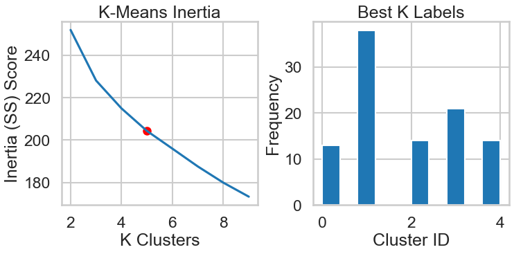

| K | Inertia | Inertia_Diff |
| --- | --- | --- |
| 2 | 251.995291 | 23.878839 |
| 3 | 228.116452 | 13.183804 |
| 4 | 214.932648 | 10.640086 |
| 5 | 204.292563 | 8.372130 |
| 6 | 195.920433 | 8.419917 |
| 7 | 187.500516 | 7.638866 |
| 8 | 179.861650 | 6.610123 |

```python
best_k = 5
best_k_labels = cluster.KMeans(n_clusters=best_k).fit_predict(x_cols)


plt.figure(figsize=(10, 5), dpi=75, facecolor='w', edgecolor='k')
plt.subplot(1,2,1)
plt.plot(Ks, ss)
plt.scatter(best_k, ss[Ks == best_k], s=100, c='r')
plt.title('K-Means Inertia')
plt.xlabel('K Clusters')
plt.ylabel('Inertia (SS) Score')


plt.subplot(1,2,2)
plt.hist(best_k_labels, rwidth=100)
plt.title('Best K Labels')
plt.xlabel('Cluster ID')
plt.ylabel('Frequency')
plt.tight_layout()
plt.show()

inertia
```

**Inertia: Best K**

> The elbow sum-of-squares method takes into consideration the squared distances of each point to its assigned cluster; the sum of all these squared distances is also known as the inertia of the clustering algorithm, and the lower the inertia value, the closer the points are to their assigned clusters. The inertia of the algorithm will continuously decrease to zero as the number of clusters increases; however, we cannot arrive at the best number of clusters by simply choosing the lowest inertia score, since that would lead to the number of clusters being equal to the number of datapoints where each datapoint is assigned a cluster. Therefore, we will select the best number of clusters to be the place where the inertia change after adding an additional cluster begins to stabilize, and as it can be seen from the dataframe above, the inertia difference between additional clusters begins to stabilize around a K cluster value of 5.

### Choosing K: The Silhouette Method

There exists another method that measures how well each datapoint $x_i$ "fits" its assigned cluster *and also* how poorly it fits into other clusters. This is a different way of looking at the same objective. Denote $a_{x_i}$ as the *average* distance from $x_i$ to all other points within its own cluster $k$. The lower the value, the better. On the other hand $b_{x_i}$ is the minimum average distance from $x_i$ to points in a different cluster, minimized over clusters. That is, compute separately for each cluster the average distance from $x_i$ to the points within that cluster, and then take the minimum. The silhouette $s(x_i)$ is defined as

$$s(x_i) = \frac{b_{x_i} - a_{x_i}}{\max{\left( a_{x_i}, b_{x_i}\right)}}$$

The silhouette score is computed on *every datapoint in every cluster*. The silhouette score ranges from -1 (a poor clustering) to +1 (a very dense clustering) with 0 denoting the situation where clusters overlap. Some criteria for the silhouette coefficient is provided in the table below.

[output not shown]

Fortunately, scikit-learn provides a function to compute this for us (phew!) called [`sklearn.metrics.silhouette_score`](http://scikit-learn.org/stable/modules/generated/sklearn.metrics.silhouette_score.html). Take a look at [this article](http://scikit-learn.org/stable/auto_examples/cluster/plot_kmeans_silhouette_analysis.html) on picking $K$ in scikit-learn, as it will help you in the next exercise set.

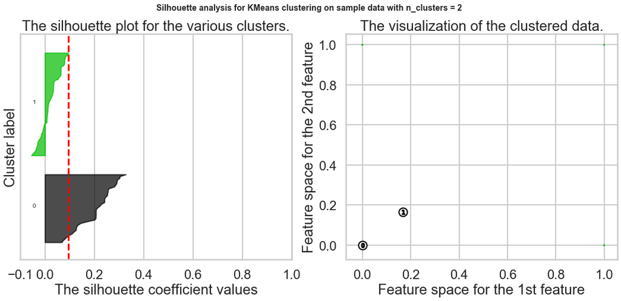

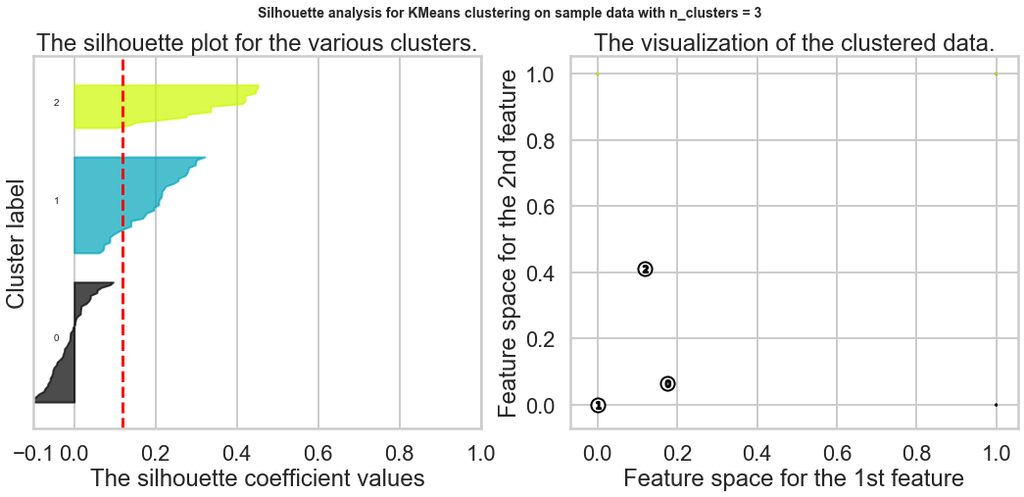

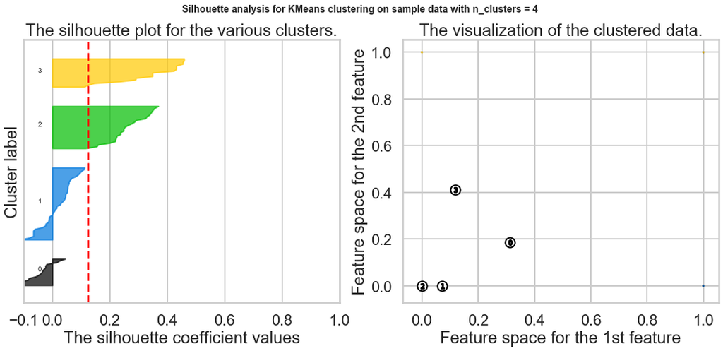

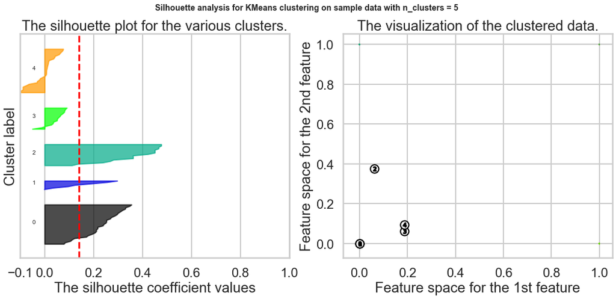

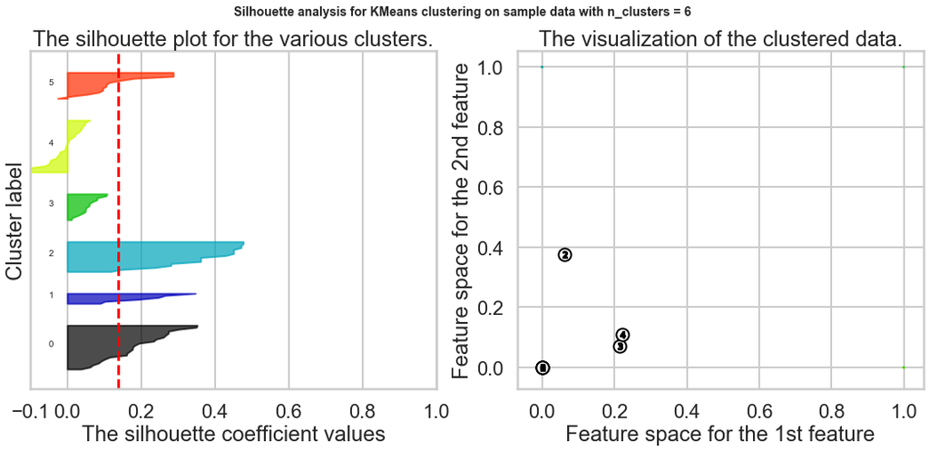

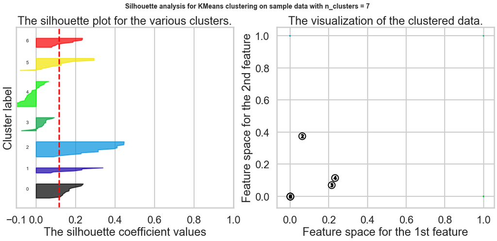

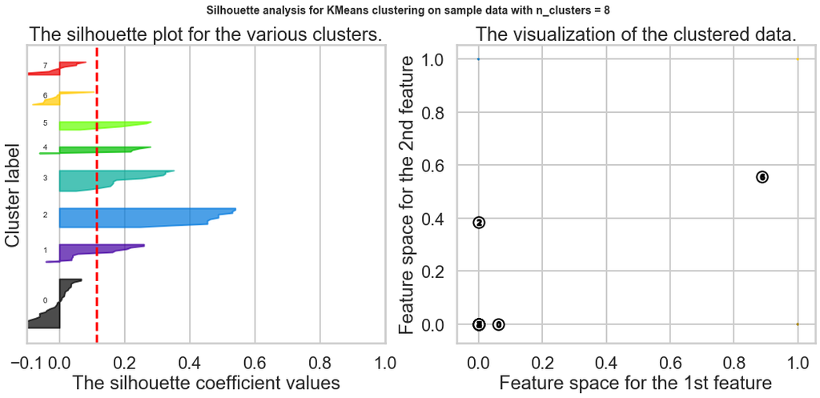

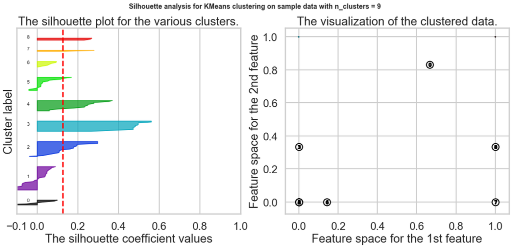

```
For n_clusters =  2 The average silhouette_score is : 0.09365573283492713
For n_clusters =  3 The average silhouette_score is : 0.11889942863638556
For n_clusters =  4 The average silhouette_score is : 0.12347053919571699
For n_clusters =  5 The average silhouette_score is : 0.14092516241984757
For n_clusters =  6 The average silhouette_score is : 0.1371798939109807
For n_clusters =  7 The average silhouette_score is : 0.1161092456616906
For n_clusters =  8 The average silhouette_score is : 0.11339573832632867
For n_clusters =  9 The average silhouette_score is : 0.12505960527779877
```

```python
from sklearn.metrics import silhouette_samples, silhouette_score
import matplotlib.cm as cm

end_averages = []

for k in range(len(Ks)):
    # Create a subplot with 1 row and 2 columns
    fig, (ax1, ax2) = plt.subplots(1, 2)
    fig.set_size_inches(18, 7)

    # The 1st subplot is the silhouette plot
    # The silhouette coefficient can range from -1, 1 but in this example all
    # lie within [-0.1, 1]
    ax1.set_xlim([-0.1, 1])
    # The (n_clusters+1)*10 is for inserting blank space between silhouette
    # plots of individual clusters, to demarcate them clearly.
    ax1.set_ylim([0, len(x_cols) + (Ks[k] + 1) * 10])

    # Initialize the clusterer with n_clusters value and a random generator
    # seed of 10 for reproducibility.
    clusterer = cluster.KMeans(n_clusters=Ks[k], random_state=10)
    cluster_labels = clusterer.fit_predict(x_cols)

    # The silhouette_score gives the average value for all the samples.
    # This gives a perspective into the density and separation of the formed
    # clusters
    silhouette_avg = silhouette_score(x_cols, cluster_labels)
    end_averages.append(silhouette_avg)

    # Compute the silhouette scores for each sample
    sample_silhouette_values = silhouette_samples(x_cols, cluster_labels)

    y_lower = 10
    for i in range(Ks[k]):
        # Aggregate the silhouette scores for samples belonging to
        # cluster i, and sort them
        ith_cluster_silhouette_values = \
            sample_silhouette_values[cluster_labels == i]

        ith_cluster_silhouette_values.sort()

        size_cluster_i = ith_cluster_silhouette_values.shape[0]
        y_upper = y_lower + size_cluster_i

        color = cm.nipy_spectral(float(i) / Ks[k])
        ax1.fill_betweenx(np.arange(y_lower, y_upper),
                          0, ith_cluster_silhouette_values,
                          facecolor=color, edgecolor=color, alpha=0.7)

        # Label the silhouette plots with their cluster numbers at the middle
        ax1.text(-0.05, y_lower + 0.5 * size_cluster_i, str(i))

        # Compute the new y_lower for next plot
        y_lower = y_upper + 10  # 10 for the 0 samples

    ax1.set_title("The silhouette plot for the various clusters.")
    ax1.set_xlabel("The silhouette coefficient values")
    ax1.set_ylabel("Cluster label")

    # The vertical line for average silhouette score of all the values
    ax1.axvline(x=silhouette_avg, color="red", linestyle="--")

    ax1.set_yticks([])  # Clear the yaxis labels / ticks
    ax1.set_xticks([-0.1, 0, 0.2, 0.4, 0.6, 0.8, 1])

    # 2nd Plot showing the actual clusters formed
    colors = cm.nipy_spectral(cluster_labels.astype(float) / Ks[k])
    ax2.scatter(x_cols[:, 0], x_cols[:, 1], marker='.', s=30, lw=0, alpha=0.7,
                c=colors, edgecolor='k')

    # Labeling the clusters
    centers = clusterer.cluster_centers_
    # Draw white circles at cluster centers
    ax2.scatter(centers[:, 0], centers[:, 1], marker='o',
                c="white", alpha=1, s=200, edgecolor='k')

    for i, c in enumerate(centers):
        ax2.scatter(c[0], c[1], marker='$%d$' % i, alpha=1,
                    s=50, edgecolor='k')

    ax2.set_title("The visualization of the clustered data.")
    ax2.set_xlabel("Feature space for the 1st feature")
    ax2.set_ylabel("Feature space for the 2nd feature")

    plt.suptitle(("Silhouette analysis for KMeans clustering on sample data "
                  "with n_clusters = %d" % Ks[k]),
                 fontsize=14, fontweight='bold')


plt.show()
for i in range(len(Ks)):
    print("For n_clusters = ", Ks[i],
          "The average silhouette_score is :", end_averages[i])
```

**Silhouette: Best K**

> The advantage the silhouette score has over the simple elbow sum-of-squares method is that on top of the inertia score within a cluster, the silhouette score takes into consideration the relative inertia from one cluster to another. This prevents the highest score corresponding to the point where the number of clusters equals the number of datapoints, because if there is a cluster really close to another cluster, the silhouette score will drop; the drop in silhouette score when additional clusters are added signifies that a lower number of clusters would not separate datapoints that should be clustered together into different clusters. After acquiring the silhouette score of different number of K clusters, the silhouette score is, consistently, the highest for a number of K clusters equal to 5.

### Choosing $K$: The Gap Statistic

There is one last method worth covering for picking $K$, the so-called Gap statistic. The computation for the gap statistic builds on the sum-of-squares established in the Elbow method discussion, and compares it to the sum-of-squares of a "null distribution," that is, a random set of points with no clustering. The estimate for the optimal number of clusters $K$ is the value for which $\log{SS}$ falls the farthest below that of the reference distribution:

$$G_k = E_n^*\{\log SS_k\} - \log SS_k$$

In other words a good clustering yields a much larger difference between the reference distribution and the clustered data. The reference distribution is a Monte Carlo (randomization) procedure that constructs $B$ random distributions of points within the bounding box (limits) of the original data and then applies K-means to this synthetic distribution of data points.. $E_n^*\{\log SS_k\}$ is just the average $SS_k$ over all $B$ replicates. We then compute the standard deviation $\sigma_{SS}$ of the values of $SS_k$ computed from the $B$ replicates of the reference distribution and compute

$$s_k = \sqrt{1+1/B}\sigma_{SS}$$

Finally, we choose $K=k$ such that $G_k \geq G_{k+1} - s_{k+1}$.

### Aside: Choosing $K$ when we Have Labels

Unsupervised learning expects that we do not have the labels. In some situations, we may wish to cluster data that is labeled. Computing the optimal number of clusters is much easier if we have access to labels. There are several methods available. We will not go into the math or details since it is rare to have access to the labels, but we provide the names and references of these measures.

- Adjusted Rand Index
- Mutual Information
- V-Measure
- Fowlkes–Mallows index

See [this article](http://scikit-learn.org/stable/modules/clustering.html) for more information about these metrics.

## Visualizing Clusters using PCA

How do we visualize clusters? If we only had two features, we could likely plot the data as is. But we have 100 data points each containing 32 features (dimensions). Principal Component Analysis (PCA) will help us reduce the dimensionality of our data from 32 to something lower. For a visualization on the coordinate plane, we will use 2 dimensions. In this exercise, we're going to use it to transform our multi-dimensional dataset into a 2 dimensional dataset.

This is only one use of PCA for dimension reduction. We can also use PCA when we want to perform regression but we have a set of highly correlated variables. PCA untangles these correlations into a smaller number of features/predictors all of which are orthogonal (not correlated). PCA is also used to reduce a large set of variables into a much smaller one.

#### 2-Dimensional PCA (Principal Component Analysis)

```python
from sklearn.decomposition import PCA

pca_two = PCA(n_components=2)
pca_two_x = pca_two.fit_transform(x_cols)
names = df_responses.index.values
cluster_id = cluster.KMeans(n_clusters=5).fit_predict(x_cols)

df_pca = pd.DataFrame(pca_two_x, columns=['x', 'y'])
df_pca['customer_name'] = names
df_pca['cluster_id'] = cluster_id
df_pca= df_pca[['customer_name', 'cluster_id', 'x', 'y']]
df_pca.head()
```

|  | customer_name | cluster_id | x | y |
| --- | --- | --- | --- | --- |
| 0 | Adams | 2 | 1.007580 | 0.108215 |
| 1 | Allen | 1 | -0.287539 | 0.044715 |
| 2 | Anderson | 3 | -0.392032 | 1.038391 |
| 3 | Bailey | 2 | 0.699477 | -0.022542 |
| 4 | Baker | 0 | 0.088183 | -0.471695 |

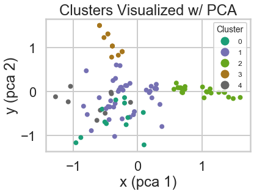

```python
fig, ax = plt.subplots()

pca_scatt = ax.scatter(df_pca.x, df_pca.y, 35, df_pca.cluster_id, 'o', 'Dark2')
pca_leg = ax.legend(*pca_scatt.legend_elements(), prop={'size':12},
                    loc='upper right', title='Cluster')
ax.set_title('Clusters Visualized w/ PCA')
ax.set_xlabel('x (pca 1)')
ax.set_ylabel('y (pca 2)')

plt.setp(pca_leg.get_title(), fontsize='14')
plt.show()
```

What we've done is we've taken those columns of 0/1 indicator variables, and we've transformed them into a 2-D dataset. We took one column and arbitrarily called it `x` and then called the other `y`. Now we can throw each point into a scatterplot. We color coded each point based on it's cluster so it's easier to see them.

**2-Component PCA Scatterplot**

> Through the use of PCA we were able to reduce our data's features to 2 components and plot the clustered datapoints against those components. The scatterplot above shows how using 5 clusters with K-Means is able to separate the datapoints pretty well with a cluster assigned to the center points and the rest of the clusters to the datapoints parting to different directions on the plot. However, an overlap can be seen between clusters which can be due to the top 2 PCA components not capturing a significant amount of explained variance corresponding to the remaining components, and therefore, in the next section, titled `Finding Best No. of Components in PCA`, we will apply the elbow method to the explained variance of all the PCA components.

#### Original Features' Correlation to their Assigned Cluster

```python
df_cluster = pd.merge(df_pca, df_transactions,
                       how='right', on='customer_name')[['customer_name', 'cluster_id', 'offer_id']]
df_cluster = pd.merge(df_cluster, df_offers, how='left', on='offer_id').drop(columns=['customer_name', 'offer_id'])
camp = pd.get_dummies(df_cluster.campaign, prefix='camp')
var = pd.get_dummies(df_cluster.varietal, prefix='var')
orig = pd.get_dummies(df_cluster.origin, prefix='orig')
cl = pd.get_dummies(df_cluster.cluster_id, prefix='Cluster')
df_cluster = pd.concat([df_cluster, cl, camp, var, orig], axis=1)
df_cluster = df_cluster.drop(columns=['cluster_id', 'campaign', 'varietal', 'origin'])

cluster_labels = ['Cluster_0', 'Cluster_1', 'Cluster_2', 'Cluster_3', 'Cluster_4']
df_corr = df_cluster.corr()[cluster_labels].drop(index=cluster_labels)
print(df_corr)

df_corr_0 = df_corr.iloc[:,0].sort_values(ascending=False)
df_corr_1 = df_corr.iloc[:,1].sort_values(ascending=False)
df_corr_2 = df_corr.iloc[:,2].sort_values(ascending=False)
df_corr_3 = df_corr.iloc[:,3].sort_values(ascending=False)
df_corr_4 = df_corr.iloc[:,4].sort_values(ascending=False)
df_corr_all = list([df_corr_0, df_corr_1, df_corr_2, df_corr_3, df_corr_4])

for df_corr_ in df_corr_all:
    print('\n----------------------------------\nCluster {} |\n----------------------------------'.format(
        df_corr_.name[8]))
    print('\n- Strongest Direct Correlations - \n\n{}'.format(np.round(df_corr_, 2).head(2).to_string()))
    print('\n- Strongest Inverse Correlations - \n\n{}'.format(np.round(df_corr_, 2).tail(2).to_string()))
```

```
                        Cluster_0  Cluster_1  Cluster_2  Cluster_3  Cluster_4
min_qty                  0.096271   0.252514  -0.559003  -0.023720   0.230264
discount                 0.093417  -0.004143  -0.099691  -0.198038   0.197064
past_peak               -0.107621   0.089548  -0.009616  -0.155594   0.131926
camp_April               0.129379   0.072629  -0.124659  -0.079244  -0.018319
camp_August              0.093410   0.091490  -0.172312  -0.109536   0.074579
camp_December            0.210631  -0.212280   0.144646  -0.131732   0.019693
camp_February           -0.115297   0.142786  -0.142980  -0.090890   0.167519
camp_January             0.032432   0.037193  -0.135877   0.125637  -0.032820
camp_July               -0.000388  -0.137425   0.145626   0.163464  -0.121671
camp_June                0.032432   0.090046  -0.135877  -0.086375   0.076431
camp_March              -0.043878  -0.006306   0.242246  -0.145551  -0.105842
camp_May                -0.088202   0.070155   0.021104  -0.095248   0.050817
camp_November           -0.084815  -0.092412   0.289376  -0.093087  -0.045609
camp_October            -0.136457   0.079232  -0.169222   0.209276   0.049833
camp_September          -0.062206  -0.069988  -0.124659   0.469954  -0.096931
var_Cabernet Sauvignon  -0.026869   0.018159  -0.175369  -0.111479   0.304275
var_Champagne            0.226901   0.135860  -0.305850  -0.194424   0.106260
var_Chardonnay           0.027859   0.130316  -0.116717  -0.074195  -0.007338
var_Espumante           -0.108375   0.015753   0.300176  -0.126381  -0.154589
var_Malbec               0.001768  -0.067109   0.224769  -0.111479  -0.077610
var_Merlot              -0.038568   0.010766   0.050141  -0.086375   0.040014
var_Pinot Grigio        -0.100523  -0.155558   0.377282  -0.079244  -0.057625
var_Pinot Noir          -0.144400  -0.180147  -0.209999   0.849500  -0.086540
var_Prosecco             0.059536   0.050163   0.056677  -0.131732  -0.083637
orig_Australia          -0.105511  -0.035290   0.079193   0.157675  -0.071575
orig_California          0.099797   0.085886  -0.120741  -0.076753  -0.012984
orig_Chile               0.034656   0.059064  -0.049453  -0.120912   0.044991
orig_France              0.126650  -0.046738   0.045033  -0.167766   0.025674
orig_Germany             0.060365  -0.119588  -0.120741   0.252936   0.027466
orig_Italy              -0.055579  -0.148405  -0.149835   0.372333   0.117747
orig_New Zealand        -0.087338   0.164137  -0.108308  -0.068850   0.049758
orig_Oregon             -0.094732   0.049854   0.145626  -0.099469  -0.057152
orig_South Africa       -0.059488   0.059805   0.154389  -0.097374  -0.119109

----------------------------------
Cluster 0 |
----------------------------------

- Strongest Direct Correlations -
```

[output cut: 49 more lines]

```
discount        -0.20

----------------------------------
Cluster 4 |
----------------------------------

- Strongest Direct Correlations -

var_Cabernet Sauvignon    0.30
min_qty                   0.23

- Strongest Inverse Correlations -

camp_July       -0.12
var_Espumante   -0.15
```

#### Finding Best No. of Components in PCA

```python
pca = PCA()
pca.fit(x_cols)

# Do the rest on your own :)
exp_var = pca.explained_variance_
cum_exp_var = np.cumsum(pca.explained_variance_ratio_)
component = np.arange(1, len(exp_var)+1)
```

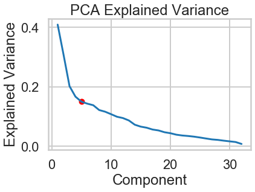

```
Scatter Point Component Value: 5
Percentage of Total Explained Variance: 43.43%
```

```python
best_c = 5
plt.plot(component, exp_var, linewidth=3)
plt.scatter(best_c, exp_var[best_c-1], s=250, c='r', marker='.')
plt.grid(True)
plt.xlabel('Component')
plt.ylabel('Explained Variance')
plt.title('PCA Explained Variance')
plt.show()

print('Scatter Point Component Value:', best_c)
print('Percentage of Total Explained Variance: {:.2f}%'.format(cum_exp_var[best_c-1] * 100))
```

#### Finding Best K Clusters w/ Five PCA Components

```python
pca_five = PCA(n_components=5)
pca_five_x = pca_five.fit_transform(x_cols)

def mean_silhouette(clusterer=None, cluster_param=True, data=pca_five_x, K_values=[5], num_runs=20):
    pca_sil = np.empty((num_runs, len(K_values)))

    for i in range(num_runs):
        for j in range(len(K_values)):
            if cluster_param:
                clusterer.n_clusters = K_values[j]
                pred = clusterer.fit_predict(data)
            else:
                pred = clusterer.fit_predict(data)
            pca_sil[i, j] = silhouette_score(x_cols, pred)

    return np.mean(pca_sil, axis=0)
```

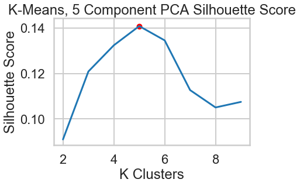

```
Max Silhouette Score: 0.1409
```

```python
Ks = np.arange(2,10)
pca_sil = mean_silhouette(clusterer=cluster.KMeans(), K_values=Ks)
kmeans_sil = max(pca_sil)

plt.plot(Ks, pca_sil)
plt.scatter(Ks[pca_sil == kmeans_sil], kmeans_sil, s=250, c='r', marker='.')
plt.title('K-Means, 5 Component PCA Silhouette Score')
plt.xlabel('K Clusters')
plt.ylabel('Silhouette Score')
plt.show()

print('Max Silhouette Score: {:.4f}'.format(kmeans_sil))
```

**Best K Clusters w/ 5 PCA**

> Using the elbow method on the explained variance plot, we deduced that anything more than 5 PCA components would yield too insignificant increases of the total explained variance; 5 PCA components yielded about 43% of the total explained variance. Furhter, in order to check if 5 K-clusters would still yield the best clustering, we plotted the silhouette score acquired by various K values; the silhouette metric was chosen due to its ability to score K values with excessive clusters lower than smaller K values that generalize better to the data. After running each K value 20 times, a plot of the average silhouette score for each K value can be seen above; it can be seen that the maximum silhouette score is achieved by a K value of 5.

## Other Clustering Algorithms

k-means is only one of a ton of clustering algorithms. Below is a brief description of several clustering algorithms, and the table provides references to the other clustering algorithms in scikit-learn.

- **Affinity Propagation** does not require the number of clusters $K$ to be known in advance! AP uses a "message passing" paradigm to cluster points based on their similarity.
- **Spectral Clustering** uses the eigenvalues of a similarity matrix to reduce the dimensionality of the data before clustering in a lower dimensional space. This is tangentially similar to what we did to visualize k-means clusters using PCA. The number of clusters must be known a priori.
- **Ward's Method** applies to hierarchical clustering. Hierarchical clustering algorithms take a set of data and successively divide the observations into more and more clusters at each layer of the hierarchy. Ward's method is used to determine when two clusters in the hierarchy should be combined into one. It is basically an extension of hierarchical clustering. Hierarchical clustering is *divisive*, that is, all observations are part of the same cluster at first, and at each successive iteration, the clusters are made smaller and smaller. With hierarchical clustering, a hierarchy is constructed, and there is not really the concept of "number of clusters." The number of clusters simply determines how low or how high in the hierarchy we reference and can be determined empirically or by looking at the [dendogram](https://docs.scipy.org/doc/scipy-0.18.1/reference/generated/scipy.cluster.hierarchy.dendrogram.html).
- **Agglomerative Clustering** is similar to hierarchical clustering but but is not divisive, it is *agglomerative*. That is, every observation is placed into its own cluster and at each iteration or level or the hierarchy, observations are merged into fewer and fewer clusters until convergence. Similar to hierarchical clustering, the constructed hierarchy contains all possible numbers of clusters and it is up to the analyst to pick the number by reviewing statistics or the dendogram.
- **DBSCAN** is based on point density rather than distance. It groups together points with many nearby neighbors. DBSCAN is one of the most cited algorithms in the literature. It does not require knowing the number of clusters a priori, but does require specifying the neighborhood size.

### Clustering Algorithms in Scikit-learn

Method name

Parameters

Scalability

Use Case

Geometry (metric used)

K-Means

number of clusters

Very largen_samples, medium n_clusters with MiniBatch code

General-purpose, even cluster size, flat geometry, not too many clusters

Distances between points

Affinity propagation

damping, sample preference

Not scalable with n_samples

Many clusters, uneven cluster size, non-flat geometry

Graph distance (e.g. nearest-neighbor graph)

Mean-shift

bandwidth

Not scalable with n_samples

Many clusters, uneven cluster size, non-flat geometry

Distances between points

Spectral clustering

number of clusters

Medium n_samples, small n_clusters

Few clusters, even cluster size, non-flat geometry

Graph distance (e.g. nearest-neighbor graph)

Ward hierarchical clustering

number of clusters

Large n_samples and n_clusters

Many clusters, possibly connectivity constraints

Distances between points

Agglomerative clustering

number of clusters, linkage type, distance

Large n_samples and n_clusters

Many clusters, possibly connectivity constraints, non Euclidean distances

Any pairwise distance

DBSCAN

neighborhood size

Very large n_samples, medium n_clusters

Non-flat geometry, uneven cluster sizes

Distances between nearest points

Gaussian mixtures

many

Not scalable

Flat geometry, good for density estimation

Mahalanobis distances to centers

Birch

branching factor, threshold, optional global clusterer.

Large n_clusters and n_samples

Large dataset, outlier removal, data reduction.

Euclidean distance between points

#### Other Clustering Algorithms

```python
aff_prop = cluster.AffinityPropagation()
aff_sil = mean_silhouette(clusterer=aff_prop, cluster_param=False)

spectral = cluster.SpectralClustering()
spec_sil = mean_silhouette(clusterer=spectral)

agglomerative = cluster.AgglomerativeClustering()
agg_sil = mean_silhouette(clusterer=agglomerative)

dbscan = cluster.DBSCAN()
db_sil = mean_silhouette(clusterer=dbscan)
```

```python
tested_alg = ['K-Means', 'Affinity Propagation', 'Spectral Clustering', 'Agglomerative Clustering', 'DBSCAN']
other_sil = pd.DataFrame([np.array([kmeans_sil]), aff_sil, spec_sil, agg_sil, db_sil],
                         columns=['Silhouette Score'], index=tested_alg)
other_sil
```

|  | Silhouette Score |
| --- | --- |
| K-Means | 0.140908 |
| Affinity Propagation | 0.102707 |
| Spectral Clustering | 0.132885 |
| Agglomerative Clustering | 0.136328 |
| DBSCAN | 0.056503 |